# Northern elephant seal gut microbiome analysis

### Overview

This document provides the R code to reproduce the figures and analyses in our paper “Early sexual dimorphism, development and genetic basis of the gut microbiome in northern elephant seals”. If you have any questions, please contact me at martin.adam.stoffel[at]gmail.com.

We collected rectal samples from 40 northern elephant seal pups across their 7-week long post-weaning period. From each individual, we collected 3 swabs at 28, 43 and 58 days of age, resulting in a total of 112 microbiome samples (some individuals died or were lost at some point).

To quantify the microbial communities, we sequenced the V3-V4 region of the 16S rRNA gene, using paired-end reads on an Illumina MiSeq. The paired-end reads were merged into amplicon sequence variants (ASVs) with DADA2. These were then assembled into a phyloseq object, sampling data (individual ID, sex etc.) was added and the microbial ASVs were either barely filtered or stringently filtered according to their prevalence and abundance. These steps can be reproduced using scripts 1_ to 3_ in the [GitHub repo](https://github.com/mastoffel/nes_microbiome).

```r
# download.file("https://github.com/mastoffel/nes_microbiome/blob/master/microbiome_composition_funs.R")
```

### Load packages

```r
library(pacman)
p_load(phyloseq, tidyverse, msa, inbreedR, rptR, lme4, DESeq2,
       dada2, phangorn, wesanderson, grid, cowplot, readxl, RColorBrewer,
       blogdown, patchwork, Demerelate, vegan, ecodist, reshape2, microbiome,
       kableExtra, forcats, broom, simpleboot)
# library(partR2)
source("martin.R")
source("microbiome_composition_funs.R")
```

### Load data

Here, we load two phyloseq objects. One is barely filtered and will be used for the analyses of alpha diversity (ps0). The other one is filter using abundances and prevalences and will be used for all other analyses.

```r
# load (mostly) unfiltered phyloseq object ps0
load("../data/processed/ps0.RData")
# load abundance and prevalence filtered phyloseq object ps3
load("../data/processed/ps3.RData")

ps0 # unfiltered
```

```
## phyloseq-class experiment-level object
## otu_table()   OTU Table:         [ 2809 taxa and 112 samples ]
## sample_data() Sample Data:       [ 112 samples by 7 sample variables ]
## tax_table()   Taxonomy Table:    [ 2809 taxa by 7 taxonomic ranks ]
## phy_tree()    Phylogenetic Tree: [ 2809 tips and 2807 internal nodes ]
```

```r
ps3 # filtered
```

```
## phyloseq-class experiment-level object
## otu_table()   OTU Table:         [ 1063 taxa and 112 samples ]
## sample_data() Sample Data:       [ 112 samples by 7 sample variables ]
## tax_table()   Taxonomy Table:    [ 1063 taxa by 7 taxonomic ranks ]
## phy_tree()    Phylogenetic Tree: [ 1063 tips and 1062 internal nodes ]
```

#### Let’s have a look at the what the phyloseq objects contain.

First of all, there is the otu_table, which in our case is a ASV table, containing the exact variants.

```r
otu_table(ps3)[1, 1:2]
```

```
## OTU Table:          [2 taxa and 1 samples]
##                      taxa are columns
##          TGGGGAATATTGGACAATGGACCAAAAGTCTGATCCAGCAATTCTGTGTGCACGATGACG…
## 17BEMa10                                                                                                                                                                                                                                                                                                 …
##          TGAGGAATATTGGTCAATGGGCGAGAGCCTGAACCAGCCAAGTAGCGTGAAGGATGAAGG…
## 17BEMa10                                                                                                                                                                                                                                                                                                 …
```

Second there is the sample data, which we added previously.

```r
sample_data(ps3)[1:3, ]
```

```
##                id territory sex timepoint individual     died
## 17BEMa10 17BEMa10         3   F        T1   17BEMa10 survived
## 17BEMa11 17BEMa11         1   M        T1   17BEMa11 survived
## 17BEMa12 17BEMa12         1   F        T1   17BEMa12     died
##          birth_territory
## 17BEMa10               3
## 17BEMa11               1
## 17BEMa12               1
```

Third, there is the taxonomy table, which assigns a taxonomy to every ASV. Here is an example for the first one.

```r
tax_table(ps3)[1, 1:3]
```

```
## Taxonomy Table:     [1 taxa by 3 taxonomic ranks]:
##                                                                                                                                                                                                                                                                                                          …
## TGGGGAATATTGGACAATGGACCAAAAGTCTGATCCAGCAATTCTGTGTGCACGATGACG… "Bacteria"
##                                                                                                                                                                                                                                                                                                          …
## TGGGGAATATTGGACAATGGACCAAAAGTCTGATCCAGCAATTCTGTGTGCACGATGACG… "Fusobacteria"
##                                                                                                                                                                                                                                                                                                          …
## TGGGGAATATTGGACAATGGACCAAAAGTCTGATCCAGCAATTCTGTGTGCACGATGACG… "Fusobacteriia"
```

The fourth part is data underlying a phylogenetic tree of all ASVs, which is not shown.

### Overall gut microbiome composition

Figure 1 shows the distribution of microbial phyla across individuals and sampling timepoints. Each bar represents one individual and each row one timepoint.

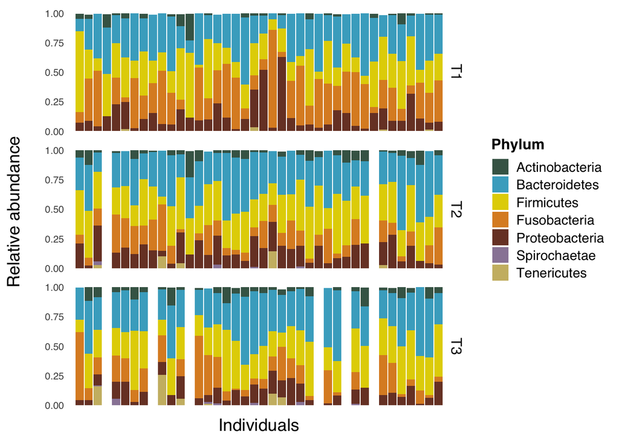

```r
# select phylum, transform to relativ abundancens and filter above 1% for plotting
nes_phylum <- ps3 %>%
  tax_glom(taxrank = "Phylum") %>%
  transform_sample_counts(function(x) {x/sum(x)}) %>%
  psmelt() %>%
  filter(Abundance > 0.01) %>%
  arrange(desc(Abundance))

# barplot
p_bar <- ggplot(nes_phylum, aes(individual, Abundance, fill = Phylum)) +
  facet_grid(timepoint~.)+
  geom_bar(stat = "identity") +
  theme_martin(base_family = "Helvetica") +
  #scale_fill_manual(values = phylum_colors) +
  theme(axis.text.x = element_blank(),
        axis.ticks = element_blank(),
        axis.title.x = element_text(size=14),
        axis.title.y = element_text(size=14),
        axis.text.y = element_text(size=8))+
  scale_fill_manual(values = c(wes_palette("Chevalier1")[1],wes_palette("FantasticFox1")[3:1],
                               wes_palette("IsleofDogs1")[c(2,1,3)] ), name = "Phylum") +
  #scale_fill_brewer(type = "qual", palette = "Set3") +
  guides(fill = guide_legend(keywidth = 1, keyheight = 1)) +
  theme(legend.text = element_text(size = 11),legend.title = element_text(face="bold")) +
  ylab("Relative abundance \n") +
  xlab("Individuals") +
  theme(panel.grid.major = element_blank(),panel.grid.minor = element_blank()) +
        #axis.line = element_line(size = 0.5, colour = "black")) +
  theme(panel.spacing.x = unit(10, "lines"))+
  theme(strip.text.y = element_text(size=12))
p_bar
```

Next, we calculate mean and sd ASVs per sample.

```r
ps_otu <- as.data.frame(otu_table(ps3))
asv_per_sample <- rowSums(ps_otu > 0)
mean(asv_per_sample)
```

```
## [1] 286.4911
```

```r
sd(asv_per_sample)
```

```
## [1] 67.00289
```

### Core gut microbiome

Supposedly, at each point during the elephant seal development, there should be a number of gut microbes which are shared by most individuals in the population, the core microbiome. Here we define the core microbiome as ASVs which are shared among at least 90% of individuals.

```r
# Calculate relative abundances
ps_rel <- microbiome::transform(ps3, "compositional")

# Core Microbiome for each timepoint
core_microbiome <- function(timepoint, ps) {
    # ps_rel_t1 <- subset_samples(ps_rel, timepoint == "T1")
    ps_tp <- prune_samples(sample_data(ps)$timepoint %in% timepoint, ps)
    # get core microbiome (prevalence = 90%)
    core_taxa_tp <- core(ps_tp, detection = 0, prevalence = 90/100)
    # function for assessing means and medians of relative abundances
    x <- otu_table(core_taxa_tp)
    # taxa_are_rows(x)
    taxa_means <- round(colMeans(x), 4)
    # taxa_medians <- apply(x, 2, median)
    # get tax table
    tp_tax_table <- as.data.frame(tax_table(core_taxa_tp)) %>%
        tibble::rownames_to_column("ASV") %>%
        mutate(`Mean rel. abundance %` = 100 * taxa_means) %>%
        arrange(desc(`Mean rel. abundance %`))
}

# three timepoints
all_timepoints <- c("T1", "T2", "T3")
core_across_time <- purrr::map(all_timepoints, core_microbiome, ps_rel)
names(core_across_time) <- all_timepoints
```

And create the Supplementary tables 1-3:

```r
# Core microbiome tables -------------------------------------------------------
linesep <- c("")

# core microbiome table in Supplementary
# uncomment lines for actually saving tables
for (i in all_timepoints) {
    core_timepoint <- dplyr::select(core_across_time[[i]], -ASV)
    kable(core_timepoint, format = "latex", booktabs = TRUE, escape = T,
          linesep = linesep, align = "l") %>%
          kable_styling(latex_options = c( "scale_down")) %>%
          row_spec(0, bold = T) # %>%
          kable_as_image(paste0("../tables/core_microbiome_", i), keep_pdf = TRUE,
                       file_format = "jpeg")
}
```

### Variance-stabilising transformation

For all analyses and plots of beta diversity, we use the variance-stabilising transformation in Deseq2 on the ASV abundance data, resulting in a new phyloseq object, ps_vst.

```r
# convert to deseq
nes_dds <- phyloseq_to_deseq2(ps3, ~1)
# estimate size factors with not including 0 in geometric mean calc
nes_dds  <- estimateSizeFactors(nes_dds, type = "poscounts") %>%
                estimateDispersions(fitType = "local")
# create new phyloseq object with variance stabilised ASV table
ps_vst <- ps3
otu_table(ps_vst) <- otu_table(getVarianceStabilizedData(nes_dds),
                               taxa_are_rows = TRUE)
```

Now we use metric dimensional scaling for plotting microbiome similarity across samples.

```r
# for plotting
get_colors <- function(pal) brewer.pal(brewer.pal.info[pal, "maxcolors"], pal)
colpal <- c(  "#0000ff", "#ffb14e", "#ea5f94"  )
colpal <- wes_palette("Moonrise2", 3, type = "discrete")

# multidimensional scaling based on bray-curtis
ps_ord <- ordinate(ps_vst, "MDS", "bray")
# calculate axis length relationships according to eigenvalues
evals <- ps_ord$values$Eigenvalues
# extract data to plot
p_ord_df <- plot_ordination(ps_vst, ps_ord, shape = "sex", color = "timepoint",
                            justDF = TRUE, axes = 1:4)
```

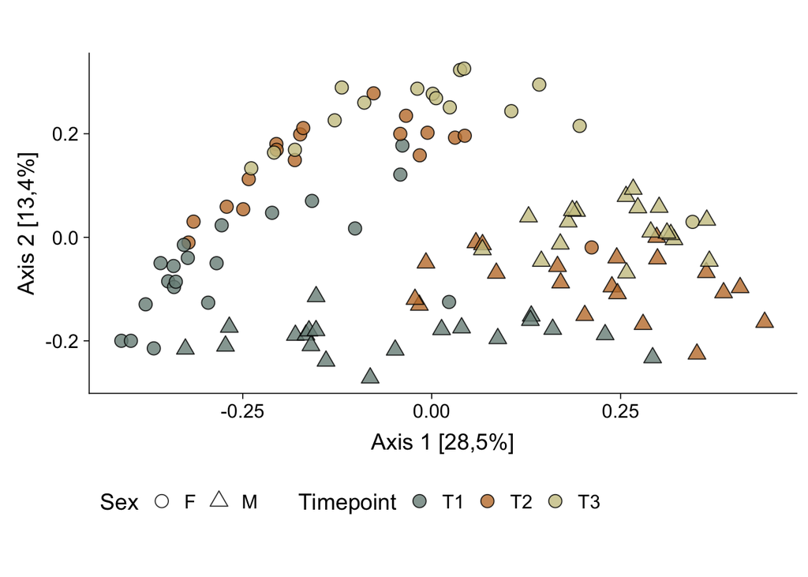

```r
# plot
p_ord_plot <- ggplot(p_ord_df, aes(Axis.1, Axis.2)) +
    geom_point(size = 3.5, alpha = 0.8, aes(shape = sex, fill = timepoint)) +
    #geom_point(size = 3, alpha = 0.8, aes( color = individual)) +
    #theme_martin() +
    scale_shape_manual(values = c(21,24), name = "Sex") +
    scale_fill_manual(values = colpal, name = "Timepoint") +
    coord_fixed(sqrt(evals[2] / evals[1])) +
    theme(legend.position = "bottom",
          legend.direction = "horizontal") +
    xlab("Axis 1 [28,5%]") +
    ylab("Axis 2 [13,4%]") +
    theme(panel.grid = element_blank(),
        axis.line.x = element_line(colour = "black", size = 0.3, linetype = 1),
        axis.line.y = element_line(colour = "black", size = 0.3, linetype = 1),
        axis.ticks = element_line(colour = "black", size = 0.3)) +
    guides(fill=guide_legend(override.aes=list(shape=21)))

p_ord_plot
```

A major advantage of longitudinal sampling is that we can actually quantify how similar repeated microbiome samples from the same individual are. We can use the same MDS plot, but this time color-code samples coming from the same individual. To avoid overplotting, we do this only for 6 out of 40 individuals.

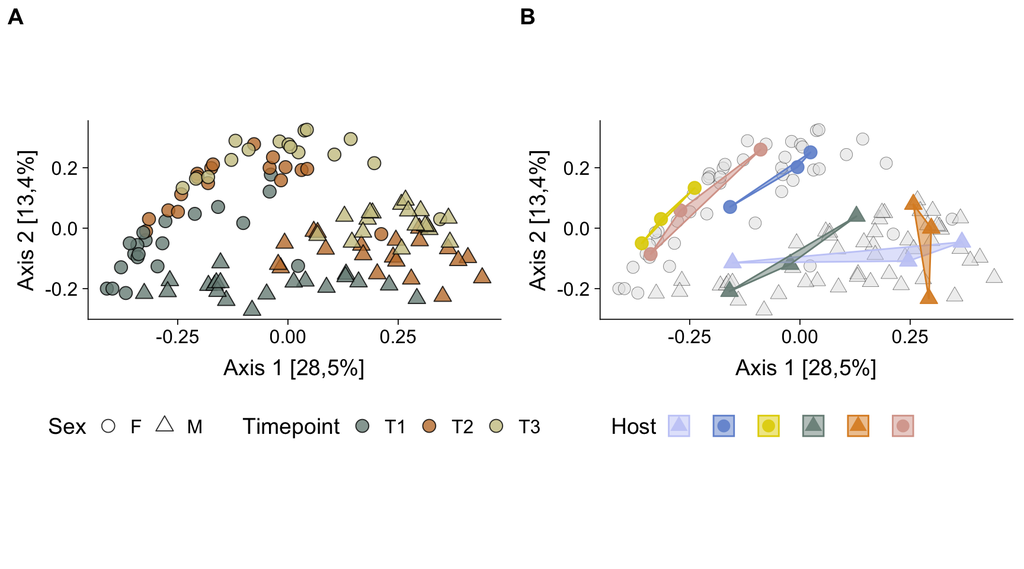

```r
set.seed(25)
plotcols <- sample(c(wes_palette("FantasticFox1")[-4], wes_palette("GrandBudapest2")[-1], wes_palette("Moonrise2")), 6)
# good inds to show
# 17BEMa32, 17BEMa27 or 24, 17BEMa38, 17BEMa3
set.seed(113)
data_sub <- filter(p_ord_df, individual %in% sample(unique(p_ord_df$individual), 8)) %>%
              filter(!(individual %in% c("17BEMa4", "17BEMa13")))

p_host <- ggplot(p_ord_df, aes(Axis.1, Axis.2, shape = sex)) +
  geom_point(size = 3.5, alpha = 0.6, fill = "grey90", stroke = 0.2) +
  geom_point(data = data_sub,
             aes(col=individual, fill=individual),
             size = 3.5, alpha = 0.9, stroke = 0.5) +
  geom_polygon(data = data_sub,
               aes(col=individual, fill=individual), alpha = 0.5, size = 0.5) + # , fill=NA
  scale_shape_manual(values = c(21,24), name = "Sex") +
 scale_x_continuous(breaks = seq(from = -0.25, to = 0.25, by = 0.25)) + # limits = c(-0.45, 0.45))
  scale_y_continuous(breaks = seq(from = -0.2, to = 0.2, by = 0.2)) + #, limits = c(-0.4, 0.4)
  #scale_shape_manual(values = c(21,2))+
  #scale_shape_manual(values = c(21,24), name = "Sex") +
  scale_color_manual(values = c(plotcols), labels = rep("", 6)) +
  scale_fill_manual(values = c(plotcols), labels = rep("", 6)) +
  coord_fixed(sqrt(evals[2] / evals[1])) +
  xlab("Axis 1 [28,5%]") +
  ylab("Axis 2 [13,4%]") +
  guides(color= FALSE, shape = FALSE,
         fill = guide_legend("Host", nrow = 1,
                             override.aes=list(fill=plotcols, col = plotcols, shape=c(17,16,16,17,17,16))),
         keywidth = 1) +
  theme(panel.grid = element_blank(),
        axis.line.x = element_line(colour = "black", size = 0.3, linetype = 1),
        axis.line.y = element_line(colour = "black", size = 0.3, linetype = 1),
        axis.ticks = element_line(colour = "black", size = 0.3),
        legend.position = "bottom")


p_full <- plot_grid(p_ord_plot, p_host, labels = c("A", "B"))
p_full
```